# Text Sources for High Gods from the Seshat Database

Analysis by Rachel Spicer, GitHub:RASpicer

# 1 Data Collection

“exportdat.csv” and “polities.csv” were obtained from https://github.com/pesavage/moralizing-gods on 20th March 2019.

Data in “HighGodSourceRaw.csv” was obtained by manually extracting and classifying data from the Seshat database (http://seshatdatabank.info/nature/) on 25th March 2019.

## 1.1 Copyright Usage Statement

This research employed data from the Seshat Databank (seshatdatabank.info) under Creative Commons Attribution Non-Commercial (CC By-NC SA) licensing (https://creativecommons.org/licenses/by-nc-sa/4.0/legalcode).

The views and conclusions contained in this document are those of the authors and should not be interpreted as representing the official positions, either expressed or implied, of the Seshat Databank, its collaborative scholarly community, or the Evolution Institute.

The above copyright notice and this permission notice shall be included in all copies or substantial portions of the Software.

THE SOFTWARE IS PROVIDED “AS IS”, WITHOUT WARRANTY OF ANY KIND, EXPRESS OR IMPLIED, INCLUDING BUT NOT LIMITED TO THE WARRANTIES OF MERCHANTABILITY, FITNESS FOR A PARTICULAR PURPOSE AND NONINFRINGEMENT. IN NO EVENT SHALL THE AUTHORS OR COPYRIGHT HOLDERS BE LIABLE FOR ANY CLAIM, DAMAGES OR OTHER LIABILITY, WHETHER IN AN ACTION OF CONTRACT, TORT OR OTHERWISE, ARISING FROM, OUT OF OR IN CONNECTION WITH THE SOFTWARE OR THE USE OR OTHER DEALINGS IN THE SOFTWARE.

## 1.2 Citation

[Whitehouse, Francois, Savage, et al. (2019) Complex societies precede moralizing gods throughout world history. Nature.](https://www.nature.com/articles/s41586-019-1043-4)

[Turchin, P. et al. (2018) Quantitative historical analysis uncovers a single dimension of complexity that structures global variation in human social organization. Proc. Natl. Acad. Sci. U. S. A. 115, E144-E151.](https://www.pnas.org/content/115/2/E144)

[Turchin, P. (2018) Fitting dynamic regression models to Seshat data. Cliodynamics 9(1):25-58.](https://escholarship.org/uc/item/99x6r11m)

[Turchin P. et al. 2015. Seshat: The Global History Databank. Cliodynamics 6(1):77-107.](https://escholarship.org/uc/item/9qx38718)

# 2 Data Analysis

Text source data for the high gods classification of polities is joined with data of time periods of each polity and the value of the high gods variable.

```r
# Load data
seshat <- read.csv("../data/exportdat.csv", stringsAsFactors = FALSE)
polities <- read.csv("../data/polities.csv", stringsAsFactors = FALSE)
high_god_source <- read.csv("../data/HighGodSourceRaw.csv", stringsAsFactors = FALSE)

# Remove polities not used in the original research Remove new NGAs
polities <- polities[polities$NGA != "Crete", ]
polities <- polities[polities$NGA != "Galilee", ]
polities <- polities[polities$NGA != "Middle Ganga", ]
#### Remove low-coverage polities causing bugs in C. Java)
polities <- polities[polities$PolID != "IdCJBun", ]
polities <- polities[polities$PolID != "IdKalin", ]
polities <- polities[polities$PolID != "EsHabsb", ]
#### Remove post-colonial polities (also see below for removing post-colonial
#### polities from NGAs with only 2 polities)
polities <- polities[polities$PolID != "USIllinL", ]
polities <- polities[polities$PolID != "GbEmpir", ]
polities <- polities[polities$PolID != "InEInCo", ]
polities <- polities[polities$PolID != "InBritP", ]
polities <- polities[polities$PolID != "RuYakuL", ]
polities <- polities[polities$PolID != "UsIroqL", ]

# Combine source data with polity data
high_god_pol <- left_join(high_god_source, polities)

# extract seshat data on Moralising High Gods
HighGod <- seshat[grep("High God", seshat$Variable), ]
colnames(HighGod)[2] <- "PolID"

# Combine with Values
high_god_data <- left_join(high_god_pol, HighGod)
# Convert to numeric for calculating MHG
high_god_data$Value.No <- revalue(high_god_data$Value.From, c(absent = "0",
    inactive = "1", active = "2", moralizing = "3", monotheistic = "1", polytheistic = "2",
    `not applicable` = "unknown", `suspected unknown` = "unknown"))
# replace unknown with NA
high_god_data$Value.No[high_god_data$Value.No == "unknown"] <- NA

# calculate MHG values
high_god_data$MoralisingHighGods <- ifelse(high_god_data$Value.No == 3, 1, 0)

# Change BCE to negative years and remove CE.  Start date
high_god_data$Date.From <- if_else(grepl("B", high_god_data$Date.From), paste0("-",
    high_god_data$Date.From), high_god_data$Date.From)
high_god_data$Date.From <- gsub("BCE", "", high_god_data$Date.From)
high_god_data$Date.From <- gsub("CE", "", high_god_data$Date.From)
# End date
high_god_data$Date.To <- if_else(grepl("B", high_god_data$Date.To), paste0("-",
    high_god_data$Date.To), high_god_data$Date.To)
high_god_data$Date.To <- gsub("BCE", "", high_god_data$Date.To)
high_god_data$Date.To <- gsub("CE", "", high_god_data$Date.To)

# if there is a data range, replace start and end dates with these values
high_god_data$Start.Date <- as.numeric(ifelse(high_god_data$Date.From != "",
    high_god_data$Date.From, high_god_data$Start))
high_god_data$End.Date <- as.numeric(ifelse(high_god_data$Date.To != "" | is.na(high_god_data$Date.From) ==
    TRUE, high_god_data$Date.To, high_god_data$End))

# replace missing start/ end dates caused because Date.To/Date.From
# contained missing values (as this polity & variable combination was not
# included in exportdat.csv; NA rather than '') with dates originally from
# polities.csv
high_god_data$Start.Date <- as.numeric(ifelse(is.na(high_god_data$Date.From) ==
    TRUE, high_god_data$Start, high_god_data$Start.Date))
high_god_data$End.Date <- as.numeric(ifelse(is.na(high_god_data$Date.To) ==
    TRUE, high_god_data$End, high_god_data$End.Date))

# select and reorder annotated high gods source data
HighGodOut <- high_god_data %>% select(NGA, PolID, Start.Date, End.Date, Value.From,
    Value.No, MoralisingHighGods, Text, Number) %>% rename(HighGods = Value.From,
    HighGods.No = Value.No, SourceText = Text)
# save annotated data
write.csv(HighGodOut, "../output/HighGodSource.csv", row.names = F)
```

# 3 Time Periods of High God Coding Justification per NGA

The time periods of each coding justification for the variable high gods (creator gods) per natural geographic area (NGA). The highest number of unique source texts used for any single NGA is 9, and there are some variables missing source texts, which are labelled as MS.

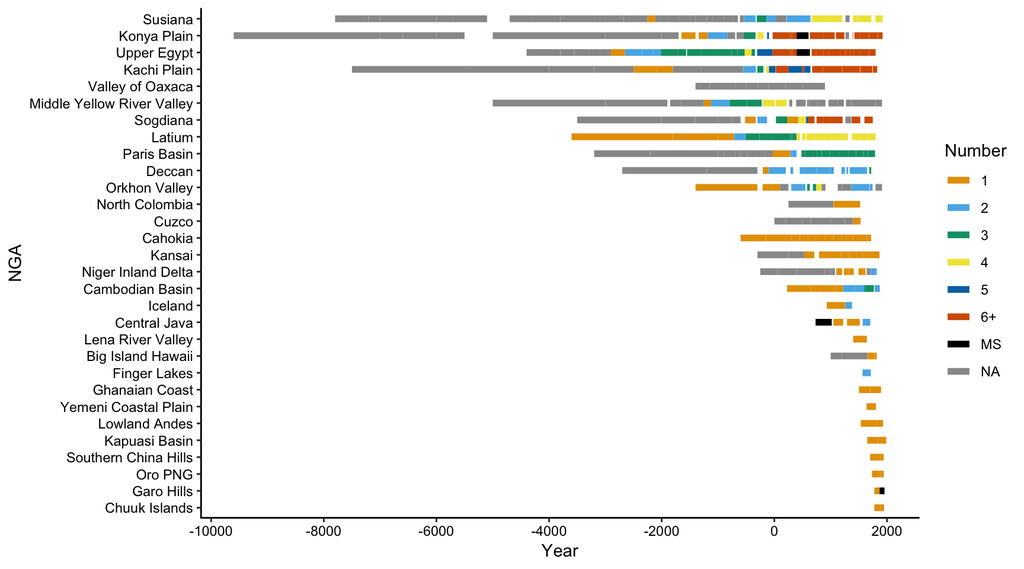

```r
# remove missing dates for plotting
high_god_data_sub <- high_god_data[!is.na(high_god_data$Start.Date), ]

# create new number variable for plotting which replaces 6-9 with 6+
high_god_data_sub$NumberFull <- high_god_data_sub$Number
high_god_data_sub$Number <- ifelse(high_god_data_sub$Number == "6" | high_god_data_sub$Number ==
    "7" | high_god_data_sub$Number == "8" | high_god_data_sub$Number == "9",
    "6+", high_god_data_sub$Number)

# plot data
ggplot(data = high_god_data_sub, aes(x = Start.Date, y = reorder(NGA, -Start.Date),
    color = Number)) + geom_segment(aes(xend = End.Date, yend = NGA), linetype = 1,
    size = 2) + scale_x_continuous(breaks = c(-10000, -8000, -6000, -4000, -2000,
    0, 2000)) + scale_color_manual(values = c("#E69F00", "#56B4E9", "#009E73",
    "#F0E442", "#0072B2", "#D55E00", "black"), na.value = "#999999") + xlab("Year") +
    ylab("NGA") + theme_bw() + theme(axis.text = element_text(colour = "black"),
    axis.line.x = element_line(color = "black", size = 0.5), axis.line.y = element_line(color = "black",
        size = 0.5), panel.grid.major = element_blank(), panel.grid.minor = element_blank(),
    panel.border = element_blank(), panel.background = element_blank())
```

```r
# save output
ggsave("../fig/HighGodSourceText.pdf", plot = last_plot(), height = 5, width = 8.5)
```

# 4 The Frequency of Use of Source Texts

The frequency each text is used a source for high gods within polities. Unfortunately the text will be harder to read, as all punctuation is removed as the source texts for some polities contain the same text but different punctuation, e.g. some include quotation marks around the whole text, whilst others do not, and in some cases "" is used, but in others ’’ is.

In total there are 50 unique source texts for high gods classification.

A majority of polities do not have a source for their high gods classification (116), however most of theses polities are classified as either unknown (5), suspected unknown (94), or have no value for high gods in ‘exportdat.csv’ (12). Only 5 polities with other classifications do not have sources (3 moralizing, 1 active and 1 inactive). Of these, USHawai, is not actually included in the original seshat analysis, as it is not included in the “polities.csv” file.

```r
# Remove all numbers from sources, as citations have different numbers for
# each entry i.e. [No.] Note this will also remove other text in square
# brackets
Text <- gsub("\\[[^\\]]*\\]", "", high_god_source$Text, perl = TRUE)

# Remove all punctuation from source texts to give an accurate number of
# different texts (some have '', whilst others do not, but the text itself
# is the same)
Text <- gsub("[^[:alnum:] ]", "", Text)

# Remove trailing spaces
Text <- gsub(" $", "", Text, perl = T)

# This still leaves some duplicates, so remove multiple spaces too
Text <- gsub("  ", " ", Text)

# make a table of the frequency of use of source texts
TextFreq <- as.data.frame(table(Text))
# rename columns
colnames(TextFreq) <- c("Text", "Frequency")

# remove missing values for table
TextFreqNoNA <- TextFreq[TextFreq$Text != "", ]

# reorder data by highest frequency
TextFreqNoNA <- TextFreqNoNA[order(-TextFreqNoNA$Freq), ]

# plot table
datatable(TextFreqNoNA, rownames = FALSE, class = "row-border hover order-column")
```

| Text | Frequency |
| --- | --- |
| Allah created and governs the cosmos At the resurrection Hashr Allah will send individuals to hell Jahannam or paradise Cannat after final judgment Hisab of their behavior eg cheating theft As an unco… | 46 |
| The Christian god is the creator of the universe omniscient and omnipotent and he punishes moral transgression fter the Resurrection when God and Jesus appear to pass judgement one must render an acco… | 23 |
| Each Purana tends to focus on a specific deity as the Supreme Being responsible for creating and ordering the world Thus Krishna is a form of the supreme God who creates maintains and destroys the uni… | 16 |
| The following quote makes it clear the Zoroastrian god Ahura Mazda was both responsible for the creation of the world and for punishing transgressors he prophet feels also the awe due to the God who i… | 13 |
| Very little is known about religious beliefs in this region before the arrival of Christianity | 12 |
| Re is the sun god His Egyptian name r is usually written with the sun disk He is often called ReHorakhty Re Horus of the Horizon this should be understood as a surname describing the character of the … | 8 |
| There are numerous Higher Gods but these are remote and sublime beings who have little involvement in human affairs Nevertheless they are subject to karma and are eventually reborn like everyone else | 8 |
| Incidents of uneasy relations between the Kami and the sovereign are based on tatari the idea that the Kami react to the breaking of taboos disrespect failure to perform expected ritual or improper ri… | 7 |
| Thomas Cressy Coded as absent due to expert confirming that high gods were not present until Christianity For the Romans proper respect for the gods and proper interpersonal behavior were both integra… | 7 |
| The most important traditional religious teaching on this subject was that the gods required people to treat strangers and suppliants well That is you should assist strangers who come to your door in … | 6 |

[output cut: 40 more lines]